# 1.

## Spring 2025 Data Analysis

## Jonah Chang, Tomas Duque, Diya

#### Contributions

Jonah Contributions: B, C, D, E, G. I wrote the introduction and data curation, and also did one section of data exploration. In addition, I designed, trained and tested machine learning model.

Tomas Contributions: A, B, C, G, E. I worked on helping find the database as well as writing the hypothesis and making the graphs for the data exploration portion. For the ML portion I made the graphs and brought together conclusions from the data exploration.

Diya Contributions: A, B, H. I contributed to selecting the startup investment dataset by researching relevant sources and evaluating its potential for analysis. I also wrote the final insights and conclusions section, summarizing our findings and tying them back to the project’s core questions.

A: Project idea

B: Dataset Curation and Preprocessing

C: Data Exploration and Summary Statistics

D: ML Algorithm Design/Development

E: ML Algorithm Training and Test Data Analysis

G: Final Tutorial Report Creation

H: Additional (not listed above)

# 2. Introduction

For this data science project we are going to analyze startup companies from a variety of different industries and countries. Startups are a crucial part of the economy as they promote innovation, new jobs, and competition. However, determining the valuation of a startup can be difficult, as there are many different factors that set them apart. With our analysis, we intend on answering the questions: What variables are strongly associated with a startups valution? and can we use those variables to accurately predict valuation or growth rate using machine learning models?

Answering these questions is important because it can help investors make better decisions about startups, and refine their investment strategies. Accurately predicting the valuation and grow rate of a startup can help investors identify high potential ventures earlier, leading to higher profits. Investing in startups can be risky due to a lot of uncertainty, so using all the tools and information at your disposal is critical.

# 3. Data Curation

Data curation is an essential part of the data life cycle and can be at times complicated. Luckily for us, our data came in a well organized and formatted csv file, so it made our data curation step very simple. In other situations, you data may not be as easily accessible, and you might have to obtain the data through web scraping or other methods. In addition, you might face issues such as innaccurate or missing values that you have to handle in order to properly analyze the data.

Data Source: https://www.kaggle.com/datasets/adilshamim8/startup-growth-and-investment-data

This database contains information about 5000 different startup companies including: Industry, Funding Rounds, Investment Amount, Valuation, Number of Investors, Country, Year Founded, and Growth Rate.

**In this case, we simply used Pandas to create a dataframe from the .csv file we were given**

```python
import pandas as pd
import numpy as np
import scipy.stats as stats
import matplotlib.pyplot as plt

df = pd.read_csv('investment_data.csv')
print(df.dtypes)


df
```

```
Startup Name                object
Industry                    object
Funding Rounds               int64
Investment Amount (USD)    float64
Valuation (USD)            float64
Number of Investors          int64
Country                     object
Year Founded                 int64
Growth Rate (%)            float64
dtype: object
```

|  | Startup Name | Industry | Funding Rounds | Investment Amount (USD) | Valuation (USD) | Number of Investors | Country | Year Founded | Growth Rate (%) |
| --- | --- | --- | --- | --- | --- | --- | --- | --- | --- |
| 0 | Startup_1 | Blockchain | 8 | 1.335166e+09 | 6.621448e+09 | 50 | Germany | 2012 | 77.10 |
| 1 | Startup_2 | SaaS | 2 | 2.781498e+09 | 8.363214e+09 | 36 | UK | 2006 | 105.52 |
| 2 | Startup_3 | EdTech | 10 | 3.309032e+09 | 1.548270e+10 | 39 | Singapore | 2016 | 190.47 |
| 3 | Startup_4 | Fintech | 5 | 4.050196e+09 | 1.268253e+10 | 44 | France | 2021 | 9.44 |
| 4 | Startup_5 | EdTech | 9 | 1.645080e+09 | 6.887966e+09 | 48 | India | 2011 | 192.00 |
| ... | ... | ... | ... | ... | ... | ... | ... | ... | ... |
| 4995 | Startup_4996 | EdTech | 5 | 4.015771e+09 | 1.212346e+10 | 29 | Germany | 2002 | 64.08 |
| 4996 | Startup_4997 | AI | 2 | 3.619535e+09 | 1.107936e+10 | 14 | Brazil | 2000 | 151.29 |
| 4997 | Startup_4998 | SaaS | 10 | 4.257640e+08 | 8.277586e+08 | 29 | UK | 2018 | 140.43 |
| 4998 | Startup_4999 | SaaS | 4 | 4.220592e+08 | 1.895497e+09 | 6 | India | 2017 | 122.93 |
| 4999 | Startup_5000 | Biotech | 5 | 1.208767e+09 | 2.265635e+09 | 8 | USA | 2010 | 71.09 |

5000 rows × 9 columns

# 4. Exploratory Data Analysis

## Hypothesis testing

- HO: The number of investors does not have an effect on the valuation
- HA: The number of investors does have an effect on the valuation

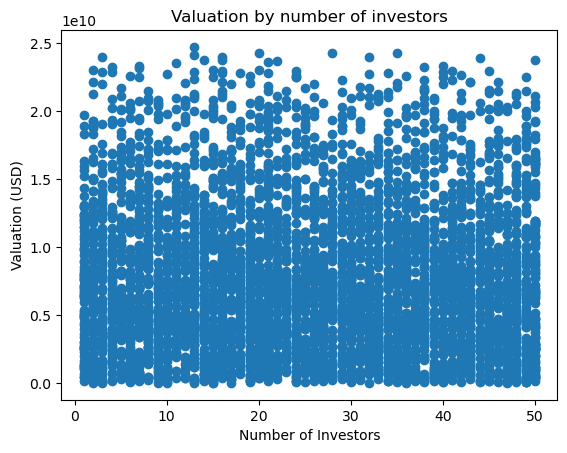

```python
plt.figure()
plt.scatter(df['Number of Investors'], df['Valuation (USD)'])
plt.xlabel('Number of Investors')
plt.ylabel('Valuation (USD)')
plt.title('Valuation by number of investors')
plt.show()
```

```python
res = stats.pearsonr(df['Valuation (USD)'], df['Number of Investors'])
print(res.pvalue)
```

```
0.2913937276637384
```

Since this value is larger than .05, we cannot reject the null hypothesis. This means that number of investors does not have an effect on valuation.

## Conclusion #2

We want to see if industry has a significant relationship with Valuation of a company?

H0: The mean valuation is the same across all industries.

HA: At least one industry has a mean valuation that is significantly different from the others

```
0.2905530906186269
```

```
Industry
AI            8.212621e+09
E-commerce    8.167838e+09
Fintech       8.117729e+09
Biotech       8.064938e+09
Blockchain    7.946256e+09
EdTech        7.938860e+09
SaaS          7.916092e+09
HealthTech    7.466786e+09
Name: Valuation (USD), dtype: float64
```

[figure not shown]

```python
from scipy.stats import f_oneway
industries = [group["Valuation (USD)"].values for name, group in df.groupby("Industry")]
anova_stat, p_val = f_oneway(*industries)
industries_names = df['Industry'].unique()
# Calculate the average valuation per industry for context
avg_valuation_by_industry = df.groupby("Industry")["Valuation (USD)"].mean().sort_values(ascending=False)

display(p_val), display(avg_valuation_by_industry)


plt.boxplot(industries, tick_labels=industries_names )
plt.title('Valuation by Industry', fontsize = 12)
plt.xticks(fontsize= 6)
plt.xlabel('Industry', fontsize=12)
plt.ylabel('Valuation in 10 Billions (USD)', fontsize=12)
plt.show()
```

Since our p value of 0.29 > 0.05 we fail reject our null hypothesis

This leads us to believe that there is no statistically significant evidence that average startup valuations differ across industries

## Conclusion #3

H0: Investment amount has no affect on valuation

HA: Investment amount has an affect on valuation

```
'P value of: 0.0'
```

```
'Correlation value of: 0.8466722515612715'
```

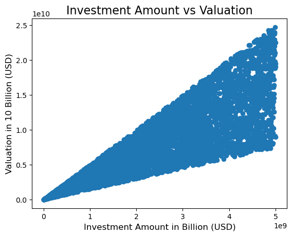

```python
from scipy.stats import spearmanr

corr_invest_val, p_val = stats.pearsonr(df["Investment Amount (USD)"], df["Valuation (USD)"])


display(f"P value of: {p_val}")
display(f"Correlation value of: {corr_invest_val}")

plt.scatter(df["Investment Amount (USD)"], df["Valuation (USD)"])
plt.title("Investment Amount vs Valuation", fontsize=16)
plt.xlabel("Investment Amount in Billion (USD)", fontsize=12)
plt.ylabel("Valuation in 10 Billion (USD)", fontsize=12)

plt.show()
```

Because of our correlation value of 0.84 and p value of 0.0 which is a lot smaller than our alpha of 0.05 we can conclude that investment amount has a posititve affect of the valuation of a company.

# 5. Primary Analysis

### Predicting startup valuation with machine learning techniques

**Before we begin our analysis we have to split up the data into two sets, one with the independent variables, and one with the target variable. Since the industry and country variables are not numbers, they have to be handeled differently. Finally, the sets are divided again into training (80%) and test (20%) sets.**

```python
from sklearn.model_selection import train_test_split, KFold
from sklearn.preprocessing import StandardScaler, OneHotEncoder
from sklearn.compose import ColumnTransformer
from sklearn.metrics import accuracy_score, classification_report, confusion_matrix, silhouette_score

categorical_features = ['Industry', 'Country']
numerical_features = ['Funding Rounds', 'Investment Amount (USD)', 'Number of Investors', 'Year Founded', 'Growth Rate (%)']

preprocessor = ColumnTransformer(
    transformers=[
        ('num', StandardScaler(), numerical_features),
        ('cat', OneHotEncoder(handle_unknown='ignore'), categorical_features)
    ])

X = df.drop('Valuation (USD)', axis=1)
y = df['Valuation (USD)']
X_train, X_test, y_train, y_test = train_test_split(X, y, test_size=0.2, random_state=42)

X_train_preprocessed = preprocessor.fit_transform(X_train)
X_test_preprocessed = preprocessor.transform(X_test)
```

**We are using three different machine learning models to see which is most accurate**

```python
from sklearn.model_selection import cross_val_score, KFold
from sklearn.tree import DecisionTreeRegressor
from sklearn.ensemble import RandomForestRegressor
from sklearn.linear_model import LinearRegression

models = {
    'Linear Regression': LinearRegression(),
    'DecisionTree': DecisionTreeRegressor(),
    'Random Forest': RandomForestRegressor()
}
k_folds = 5
seed = 42
kf = KFold(n_splits=k_folds, shuffle=True, random_state=seed)

for model_name, model in models.items():
    np.random.seed(42)
    score = cross_val_score(model, X_train_preprocessed, y_train, cv=kf, scoring='neg_mean_squared_error')
    print(f"{model_name} - Mean MSE: {(-score).mean():.4f}, Standard Deviation: {score.std():.4f}")
```

```
Linear Regression - Mean MSE: 8558262918288427008.0000, Standard Deviation: 302142374532985536.0000
DecisionTree - Mean MSE: 17622301732825235456.0000, Standard Deviation: 513435204274613504.0000
Random Forest - Mean MSE: 9154376759159248896.0000, Standard Deviation: 406620404202266112.0000
```

```python
from sklearn.metrics import mean_squared_error, r2_score

for model_name, model in models.items():
    np.random.seed(42)
    model.fit(X_train_preprocessed, y_train)

predictions = {}

for model_name, model in models.items():
    np.random.seed(42)
    y_pred = model.predict(X_test_preprocessed)
    mse = mean_squared_error(y_test, y_pred)
    r2 = r2_score(y_test, y_pred)
    predictions[model_name] = y_pred
    print(f"MSE: {mse:.3f}, R2: {r2:.3f}")
```

```
MSE: 8480227407317256192.000, R2: 0.707
MSE: 17474584038727524352.000, R2: 0.396
MSE: 8768041599909803008.000, R2: 0.697
```

**These results show that the linear regression model has the highest R2 score meaning that it captures the most variance out of the models. Since the valuations are very large numbers the mean squared error value is also very large**

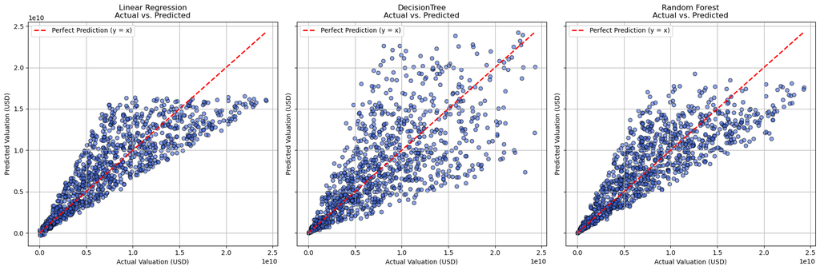

```python
n_models = 3
fig, axes = plt.subplots(1, n_models, figsize=(6 * n_models, 6), sharey=True)
for ax, (model_name, y_pred) in zip(axes, predictions.items()):
    ax.scatter(y_test, y_pred, alpha=0.6, color='royalblue', edgecolor='k')
    ax.plot([y_test.min(), y_test.max()], [y_test.min(), y_test.max()], 'r--', lw=2, label='Perfect Prediction (y = x)')
    ax.set_xlabel('Actual Valuation (USD)')
    ax.set_ylabel('Predicted Valuation (USD)')
    ax.set_title(f'{model_name}\nActual vs. Predicted')
    ax.legend()
    ax.grid(True)

plt.tight_layout()
plt.show()
```

**Here we see that the model is much better at predicting lower valuations than higher ones. Values above the red line mean that the model predicted a higher valuation than actual value, and below means the prediction was smaller**

# 6. Visualizations

```python
import matplotlib.pyplot as plt

mse_scores = {}
r2_scores = {}
predictions = {}

for model_name, model in models.items():
    model.fit(X_train_preprocessed, y_train)
    y_pred = model.predict(X_test_preprocessed)
    predictions[model_name] = y_pred
    mse_scores[model_name] = mean_squared_error(y_test, y_pred)
    r2_scores[model_name] = r2_score(y_test, y_pred)
    print(f"{model_name} — MSE: {mse_scores[model_name]:.3f}, R²: {r2_scores[model_name]:.3f}")
```

[output not shown]

[figure not shown]

[figure not shown]

```python
import matplotlib.pyplot as plt

# Bar chart for MSE
plt.figure(figsize=(5, 5))

bars = plt.bar(mse_scores.keys(), mse_scores.values(), color='blue')
for bar in bars:
    height = bar.get_height()
    plt.axhline(y=height, linestyle='--', color='black', linewidth=1)

plt.axhline(y=0, linestyle='--', color='black', label='Model\'s MSE Value Line')

plt.title('Mean Squared Error')
plt.ylabel('MSE (lower is better)')
plt.xlabel('Model')
plt.grid(axis='y')
plt.legend()
plt.tight_layout()
plt.show()

# Bar chart for R^2
plt.figure(figsize=(5, 5))

bars = plt.bar(r2_scores.keys(), r2_scores.values(), color='red')

for bar in bars:
    height = bar.get_height()
    plt.axhline(y=height, linestyle='--', color='black', linewidth=1)

plt.axhline(y=0, linestyle='--', color='black', label='Model\'s R^2 Value Line')


plt.title('R^2 Score')
plt.ylabel('R^2 Value')
plt.xlabel('Model')
plt.grid(axis='y')
plt.legend()
plt.tight_layout()
plt.show()
```

To compare model performance, we visualized the Mean Squared Error (MSE) and R² scores across three regressors: Linear Regression, Decision Tree, and Random Forest. We used bar charts to display each model’s test set performance. We marked a dotted horizontal lines to make it visually easy to compare values of different models.

In contrast, the decision Ttee showed more variability, and the random forest model underperformed slightly in comparison to the linear regression model. With these conclusions we can assume that the linear model is the most effective for our dataset.

# 7. Insights and Conclusions

### Key points from the Data Analysis:

By looking at our data analysis readers both informed and uninformed could could gain valuable insight on startups that they would like to take a risk in investing in. They can see what metrics and values they want to look at when trying to identify information about a prospecting start-up.

### Conclusion

Ultimately, this project showed how data science can support better decision-making in startup investing. Our results can guide investors in identifying early signals of high-potential startups and highlight areas for further analysis. The full pipeline—from data acquisition to hypothesis testing to modeling—gave us hands-on experience with real-world data challenges, and we’re proud of how our work connects technical insights with practical relevance in the investment space.